# Data Cleaning and Analysis of Q Cup 2018 Coffee Ratings using Python

A project for course "Data Exploration using Python" (STA 4243) at the University of Texas at San Antonio (UTSA)

Participants: Robert Hall, Max Moran, Ryan Berberek, Dulce Ximena Cid Sanabria

1. Preface and Data Dictionary
2. Data and Library Importation
3. Exploratory Data Analysis & Cleaning
4. Quality Category Questions
   - What palate-related variable has the highest correlation with score?
   - Are there statistically significant diferences in palate-related quantifications with respect to diferent countries of origin?
   - Is there a correlation between altitude and certain taste quantifications?
5. Location Metadata Questions
   - What countries have the highest overall score?
   - Which countries produce the most amounts of coffee?
   - What location-related variable has the highest correlation with score?
6. Bean Metadata Questions
   - Which processing method is used the most?
   - Which processing method has the highest number of bags?
   - Did any product get graded the same year it was harvested?

## Preface

### Midterm Project Dataset Choice: Coffee

We chose the coffee dataset because of our group’s history with and enjoyment of the drink. We also considered how we might be biased when analyzing other options.

Our group approached the Coffee Quality Union's 2018 dataset with a focus on exploratory analysis to answer our profiling questions from our preliminary report, largely from correlating to final score, but with some correlations relating individual *Quality* category variables to *Location Metadat* such as Country or Region. We visualized and described our results to better outline the answers to these questions.

## Data Dictionary

We separated variables by categories defined in the original "Coffee Quality Database" by James LeDoux, as well as some distinctions we made from our understanding.

| Quality | Description |
| --- | --- |
| Aftertaste | The length of positive flavor (taste and aroma) qualities emanating from the back of the palate and remaining after the coffee is expectorated or swallowed. If the aftertaste were short or unpleasant,… |
| Aroma | The smell of the coffee when infused with hot water. |
| Acidity | Acidity is often described as "brightness" when favorable or "sour" when unfavorable. The final score marked on the horizontal tick-mark scale should reflect the panelist's perceived quality for the A… |
| Body | Subfield of flavor. The score given for Flavor should account for the intensity, quality and complexity of its combined taste and aroma, experienced when the coffee is slurped into the mouth vigorousl… |
| Balance | Subfield of flavor. See above. |
| Clean Cup | The lack of interfering negative impressions from first ingestion to final aftertaste, a "transparency" of cup. |
| Uniformity | Uniformity refers to consistency of flavor of the different cups of the sample tasted. If the cups taste different, the rating of this aspect would not be as high. |
| Sweetness | Scalar subfield of flavor. See above. |
| Moisture | Subfield of flavor. Percentage format. |

| Bean Metadata | Description |
| --- | --- |
| Processing Method | Method for processing the beans. |
| Color | Color of the beans. |
| Species | Either Arabica or Robusta. |
| Variety | Variety of the beans. |
| Quakers | Count of Quakers in the beans sample. Quakers are under-developed coffee beans that can impact the flavor of coffee, as they look the same as regular beans. They can taste dry, ashy, bitter, astringen… |
| Category One Defects | "Category 1" defects are considered primary defects that significantly impact the taste of the coffee, like fully black beans, full sour beans, or pods. |
| Category Two Defects | "Category 2" defects are secondary defects that have a less severe impact on taste, including things like broken beans, small sticks, or partial black beans. |
| # of Bags | Number of bags tested. |
| Bag Weight | Bag weight tested. |
| Grading Date | When the beans were graded. |
| Expiration Date | Expiration date of the beans. |

| Location Metadata | Description |
| --- | --- |
| Owner | Who owns the beans. |
| Country | Where the beans came from. |
| Region | Region where beans came from. |
| Company | Name of the company that managed the beans. |
| Farm | Name of the farm that grew the beans. |
| Producer | Producer of the roasted bean. |
| Lot | Lot number of the tested beans. |
| Mill | Mill where the beans were processed. |
| Altitude (Low, High, Mean) | Altitude low, high, and mean meters. |

| Q Grader Metadata | Description |
| --- | --- |
| Certification Body | Who certified the sample grade. |
| ICO Number | International Coffee Organization number. |
| Unit of Measurement | Unit of measurement. |

## Data and Library Importation

```python
import pandas as pd
import matplotlib.pyplot as plt
import seaborn as sns
import plotly.express as px
import re
coffee = pd.read_csv('coffee_ratings.csv')
```

```python
coffee.head()
```

|  | total_cup_points | species | owner | country_of_origin | farm_name | lot_number | mill | ico_number | company | altitude | ... | color | category_two_defects | expiration | certification_body | certification_address | certification_contact | unit_of_measurement | altitude_low_meters | altitude_high_meters | altitude_mean_meters |
| --- | --- | --- | --- | --- | --- | --- | --- | --- | --- | --- | --- | --- | --- | --- | --- | --- | --- | --- | --- | --- | --- |
| 0 | 90.58 | Arabica | metad plc | Ethiopia | metad plc | NaN | metad plc | 2014/2015 | metad agricultural developmet plc | 1950-2200 | ... | Green | 0 | April 3rd, 2016 | METAD Agricultural Development plc | 309fcf77415a3661ae83e027f7e5f05dad786e44 | 19fef5a731de2db57d16da10287413f5f99bc2dd | m | 1950.0 | 2200.0 | 2075.0 |
| 1 | 89.92 | Arabica | metad plc | Ethiopia | metad plc | NaN | metad plc | 2014/2015 | metad agricultural developmet plc | 1950-2200 | ... | Green | 1 | April 3rd, 2016 | METAD Agricultural Development plc | 309fcf77415a3661ae83e027f7e5f05dad786e44 | 19fef5a731de2db57d16da10287413f5f99bc2dd | m | 1950.0 | 2200.0 | 2075.0 |
| 2 | 89.75 | Arabica | grounds for health admin | Guatemala | san marcos barrancas "san cristobal cuch | NaN | NaN | NaN | NaN | 1600 - 1800 m | ... | NaN | 0 | May 31st, 2011 | Specialty Coffee Association | 36d0d00a3724338ba7937c52a378d085f2172daa | 0878a7d4b9d35ddbf0fe2ce69a2062cceb45a660 | m | 1600.0 | 1800.0 | 1700.0 |
| 3 | 89.00 | Arabica | yidnekachew dabessa | Ethiopia | yidnekachew dabessa coffee plantation | NaN | wolensu | NaN | yidnekachew debessa coffee plantation | 1800-2200 | ... | Green | 2 | March 25th, 2016 | METAD Agricultural Development plc | 309fcf77415a3661ae83e027f7e5f05dad786e44 | 19fef5a731de2db57d16da10287413f5f99bc2dd | m | 1800.0 | 2200.0 | 2000.0 |
| 4 | 88.83 | Arabica | metad plc | Ethiopia | metad plc | NaN | metad plc | 2014/2015 | metad agricultural developmet plc | 1950-2200 | ... | Green | 2 | April 3rd, 2016 | METAD Agricultural Development plc | 309fcf77415a3661ae83e027f7e5f05dad786e44 | 19fef5a731de2db57d16da10287413f5f99bc2dd | m | 1950.0 | 2200.0 | 2075.0 |

5 rows × 43 columns

## Exploratory Data Analysis

```python
coffee.dtypes
```

```
total_cup_points         float64
species                   object
owner                     object
country_of_origin         object
farm_name                 object
lot_number                object
mill                      object
ico_number                object
company                   object
altitude                  object
region                    object
producer                  object
number_of_bags             int64
bag_weight                object
in_country_partner        object
harvest_year              object
grading_date              object
owner_1                   object
variety                   object
processing_method         object
aroma                    float64
flavor                   float64
aftertaste               float64
acidity                  float64
body                     float64
balance                  float64
uniformity               float64
clean_cup                float64
sweetness                float64
cupper_points            float64
moisture                 float64
category_one_defects       int64
quakers                  float64
color                     object
category_two_defects       int64
expiration                object
certification_body        object
certification_address     object
certification_contact     object
unit_of_measurement       object
altitude_low_meters      float64
altitude_high_meters     float64
altitude_mean_meters     float64
dtype: object
```

```python
coffee.columns
```

```
Index(['total_cup_points', 'species', 'owner', 'country_of_origin',
       'farm_name', 'lot_number', 'mill', 'ico_number', 'company', 'altitude',
       'region', 'producer', 'number_of_bags', 'bag_weight',
       'in_country_partner', 'harvest_year', 'grading_date', 'owner_1',
       'variety', 'processing_method', 'aroma', 'flavor', 'aftertaste',
       'acidity', 'body', 'balance', 'uniformity', 'clean_cup', 'sweetness',
       'cupper_points', 'moisture', 'category_one_defects', 'quakers', 'color',
       'category_two_defects', 'expiration', 'certification_body',
       'certification_address', 'certification_contact', 'unit_of_measurement',
       'altitude_low_meters', 'altitude_high_meters', 'altitude_mean_meters'],
      dtype='object')
```

```python
for i in coffee.columns:
    if pd.api.types.is_numeric_dtype(coffee[str(i)]):
        print(f"Column {str(i)} Maximum: {coffee[str(i)].max()}")
        print(f"Column {str(i)} Minimum: {coffee[str(i)].min()}")
        print('\n')
    else:
        continue
```

```
Column total_cup_points Maximum: 90.58
Column total_cup_points Minimum: 0.0


Column number_of_bags Maximum: 1062
Column number_of_bags Minimum: 0


Column aroma Maximum: 8.75
Column aroma Minimum: 0.0


Column flavor Maximum: 8.83
Column flavor Minimum: 0.0


Column aftertaste Maximum: 8.67
Column aftertaste Minimum: 0.0


Column acidity Maximum: 8.75
Column acidity Minimum: 0.0


Column body Maximum: 8.58
Column body Minimum: 0.0


Column balance Maximum: 8.75
Column balance Minimum: 0.0


Column uniformity Maximum: 10.0
Column uniformity Minimum: 0.0


Column clean_cup Maximum: 10.0
Column clean_cup Minimum: 0.0


```

[output cut: 19 more lines]

```

Column category_two_defects Maximum: 55
Column category_two_defects Minimum: 0


Column altitude_low_meters Maximum: 190164.0
Column altitude_low_meters Minimum: 1.0


Column altitude_high_meters Maximum: 190164.0
Column altitude_high_meters Minimum: 1.0


Column altitude_mean_meters Maximum: 190164.0
Column altitude_mean_meters Minimum: 1.0
```

```python
print(coffee['species'].value_counts())
```

```
species
Arabica    1311
Robusta      28
Name: count, dtype: int64
```

## What palate-related variable has the highest correlation with score?

### Features:

- Aftertaste
- Aroma
- Acidity
- Body
- Balance
- Clean Cup
- Uniformity
- Sweetness
- Moisture

```python
coffee.columns
```

```
Index(['total_cup_points', 'species', 'owner', 'country_of_origin',
       'farm_name', 'lot_number', 'mill', 'ico_number', 'company', 'altitude',
       'region', 'producer', 'number_of_bags', 'bag_weight',
       'in_country_partner', 'harvest_year', 'grading_date', 'owner_1',
       'variety', 'processing_method', 'aroma', 'flavor', 'aftertaste',
       'acidity', 'body', 'balance', 'uniformity', 'clean_cup', 'sweetness',
       'cupper_points', 'moisture', 'category_one_defects', 'quakers', 'color',
       'category_two_defects', 'expiration', 'certification_body',
       'certification_address', 'certification_contact', 'unit_of_measurement',
       'altitude_low_meters', 'altitude_high_meters', 'altitude_mean_meters'],
      dtype='object')
```

```python
coffee_salient = coffee[['total_cup_points', 'aftertaste', 'aroma', 'acidity', 'body', 'balance', 'clean_cup', 'uniformity', 'sweetness', 'moisture']]
```

```python
coffee_salient.head()
```

|  | total_cup_points | aftertaste | aroma | acidity | body | balance | clean_cup | uniformity | sweetness | moisture |
| --- | --- | --- | --- | --- | --- | --- | --- | --- | --- | --- |
| 0 | 90.58 | 8.67 | 8.67 | 8.75 | 8.50 | 8.42 | 10.0 | 10.0 | 10.0 | 0.12 |
| 1 | 89.92 | 8.50 | 8.75 | 8.58 | 8.42 | 8.42 | 10.0 | 10.0 | 10.0 | 0.12 |
| 2 | 89.75 | 8.42 | 8.42 | 8.42 | 8.33 | 8.42 | 10.0 | 10.0 | 10.0 | 0.00 |
| 3 | 89.00 | 8.42 | 8.17 | 8.42 | 8.50 | 8.25 | 10.0 | 10.0 | 10.0 | 0.11 |
| 4 | 88.83 | 8.25 | 8.25 | 8.50 | 8.42 | 8.33 | 10.0 | 10.0 | 10.0 | 0.12 |

```python
coffee_salient.isnull().sum()
```

```
total_cup_points    0
aftertaste          0
aroma               0
acidity             0
body                0
balance             0
clean_cup           0
uniformity          0
sweetness           0
moisture            0
dtype: int64
```

```python
features = coffee_salient[['aftertaste', 'aroma', 'acidity', 'body', 'balance', 'clean_cup', 'uniformity', 'sweetness', 'moisture']]
labels = coffee_salient[['total_cup_points']]
```

```python
from sklearn.model_selection import train_test_split
x_train, x_test, y_train, y_test = train_test_split(features, labels, train_size=0.8, test_size=0.2)
```

```python
from sklearn.linear_model import LinearRegression
mlr = LinearRegression()
model = mlr.fit(x_train, y_train)
points_pred = model.predict(x_test)
```

```python
print(features.columns)
```

```
Index(['aftertaste', 'aroma', 'acidity', 'body', 'balance', 'clean_cup',
       'uniformity', 'sweetness', 'moisture'],
      dtype='object')
```

```python
print(model.coef_)
```

```
[[ 2.00400516  1.37028995  1.35722394  1.01813385  1.25146642  1.07020813
   1.02907161  0.95320076 -0.35219   ]]
```

```python
coefs = []
for subset in model.coef_:
    for coef in subset:
        coefs.append(round(coef, 4))

print(coefs)

cols = [col for col in features.columns]
print(cols)

feature_coefs = pd.DataFrame({'features': cols,
                              'coefficients': coefs})

feature_coefs.sort_values('coefficients', ascending=False)
feature_coefs
```

```
[2.004, 1.3703, 1.3572, 1.0181, 1.2515, 1.0702, 1.0291, 0.9532, -0.3522]
['aftertaste', 'aroma', 'acidity', 'body', 'balance', 'clean_cup', 'uniformity', 'sweetness', 'moisture']
```

|  | features | coefficients |
| --- | --- | --- |
| 0 | aftertaste | 2.0040 |
| 1 | aroma | 1.3703 |
| 2 | acidity | 1.3572 |
| 3 | body | 1.0181 |
| 4 | balance | 1.2515 |
| 5 | clean_cup | 1.0702 |
| 6 | uniformity | 1.0291 |
| 7 | sweetness | 0.9532 |
| 8 | moisture | -0.3522 |

## Are there statistically significant diferences in palate-related quantifications with respect to diferent countries of origin?

In order to reduce overcomplication, only six nations of the many surveyed were chosen for this study. Countries were not randomly selected, and chosen based on geographical representation.

```python
coffee['country_of_origin'].value_counts()
```

```
country_of_origin
Mexico                          236
Colombia                        183
Guatemala                       181
Brazil                          132
Taiwan                           75
United States (Hawaii)           73
Honduras                         53
Costa Rica                       51
Ethiopia                         44
Tanzania, United Republic Of     40
Uganda                           36
Thailand                         32
Nicaragua                        26
Kenya                            25
El Salvador                      21
Indonesia                        20
China                            16
India                            14
Malawi                           11
United States                    10
Peru                             10
Myanmar                           8
Vietnam                           8
Haiti                             6
Philippines                       5
United States (Puerto Rico)       4
Panama                            4
Ecuador                           3
Laos                              3
Burundi                           2
Papua New Guinea                  1
Rwanda                            1
Zambia                            1
Japan                             1
Mauritius                         1
Cote d?Ivoire                     1
Name: count, dtype: int64
```

```python
top8 = coffee[coffee['country_of_origin'].isin(['Mexico',
                                         'Brazil',
                                         'Taiwan',
                                         'Ethiopia',
                                         'Tanzania, United Republic Of',
                                         'Indonesia'])]

top8['country_of_origin'].replace('Tanzania, United Republic Of', 'Tanzania')

top8['country_of_origin'].value_counts()
```

```
country_of_origin
Mexico                          236
Brazil                          132
Taiwan                           75
Ethiopia                         44
Tanzania, United Republic Of     40
Indonesia                        20
Name: count, dtype: int64
```

```python
from statsmodels.stats.multicomp import pairwise_tukeyhsd
sig = 0.05 # significance threshold
tukey_results = pairwise_tukeyhsd(top8['aftertaste'], top8['country_of_origin'], sig)
print(tukey_results)
# under the “reject” column, if True, then there is a significant difference; if False, no significant difference.
```

```
             Multiple Comparison of Means - Tukey HSD, FWER=0.05
=============================================================================
  group1             group2            meandiff p-adj   lower   upper  reject
-----------------------------------------------------------------------------
   Brazil                     Ethiopia   0.4533    0.0  0.3038  0.6028   True
   Brazil                    Indonesia   -0.025 0.9993 -0.2311   0.181  False
   Brazil                       Mexico  -0.2125    0.0 -0.3058 -0.1191   True
   Brazil                       Taiwan  -0.0451  0.905 -0.1692  0.0791  False
   Brazil Tanzania, United Republic Of  -0.0155 0.9997 -0.1705  0.1395  False
 Ethiopia                    Indonesia  -0.4784    0.0 -0.7099 -0.2468   True
 Ethiopia                       Mexico  -0.6658    0.0 -0.8068 -0.5248   True
 Ethiopia                       Taiwan  -0.4984    0.0 -0.6615 -0.3353   True
 Ethiopia Tanzania, United Republic Of  -0.4689    0.0 -0.6565 -0.2813   True
Indonesia                       Mexico  -0.1874 0.0808 -0.3874  0.0125  False
Indonesia                       Taiwan    -0.02 0.9998 -0.2361  0.1961  False
Indonesia Tanzania, United Republic Of   0.0095    1.0 -0.2257  0.2447  False
   Mexico                       Taiwan   0.1674 0.0004  0.0536  0.2812   True
   Mexico Tanzania, United Republic Of   0.1969 0.0019  0.0501  0.3438   True
   Taiwan Tanzania, United Republic Of   0.0295 0.9961 -0.1386  0.1977  False
-----------------------------------------------------------------------------
```

```python
from statsmodels.stats.multicomp import pairwise_tukeyhsd
sig = 0.05 # significance threshold
tukey_results = pairwise_tukeyhsd(top8['acidity'], top8['country_of_origin'], sig)
print(tukey_results)
# under the “reject” column, if True, then there is a significant difference; if False, no significant difference.
```

```
   Multiple Comparison of Means - Tukey HSD, FWER=0.05
==========================================================
  group1    group2  meandiff p-adj   lower   upper  reject
----------------------------------------------------------
   Brazil  Ethiopia   0.5322    0.0  0.3957  0.6687   True
   Brazil Indonesia  -0.0204 0.9996 -0.2087  0.1678  False
   Brazil    Mexico  -0.0831  0.061 -0.1683  0.0022  False
   Brazil    Taiwan   -0.096 0.1511 -0.2094  0.0174  False
   Brazil  Tanzania  -0.0114 0.9999  -0.153  0.1301  False
 Ethiopia Indonesia  -0.5526    0.0 -0.7642 -0.3411   True
 Ethiopia    Mexico  -0.6153    0.0 -0.7441 -0.4865   True
 Ethiopia    Taiwan  -0.6282    0.0 -0.7771 -0.4792   True
 Ethiopia  Tanzania  -0.5436    0.0  -0.715 -0.3723   True
Indonesia    Mexico  -0.0627 0.9239 -0.2453    0.12  False
Indonesia    Taiwan  -0.0755 0.8836 -0.2729  0.1219  False
Indonesia  Tanzania    0.009    1.0 -0.2058  0.2238  False
   Mexico    Taiwan  -0.0129 0.9993 -0.1169  0.0911  False
   Mexico  Tanzania   0.0717 0.6464 -0.0625  0.2058  False
   Taiwan  Tanzania   0.0845  0.616  -0.069  0.2381  False
----------------------------------------------------------
```

```python
from statsmodels.stats.multicomp import pairwise_tukeyhsd
sig = 0.05 # significance threshold
tukey_results = pairwise_tukeyhsd(top8['aftertaste'], top8['country_of_origin'], sig)
print(tukey_results)
# under the “reject” column, if True, then there is a significant difference; if False, no significant difference.
```

```
   Multiple Comparison of Means - Tukey HSD, FWER=0.05
==========================================================
  group1    group2  meandiff p-adj   lower   upper  reject
----------------------------------------------------------
   Brazil  Ethiopia   0.4533    0.0  0.3038  0.6028   True
   Brazil Indonesia   -0.025 0.9993 -0.2311   0.181  False
   Brazil    Mexico  -0.2125    0.0 -0.3058 -0.1191   True
   Brazil    Taiwan  -0.0451  0.905 -0.1692  0.0791  False
   Brazil  Tanzania  -0.0155 0.9997 -0.1705  0.1395  False
 Ethiopia Indonesia  -0.4784    0.0 -0.7099 -0.2468   True
 Ethiopia    Mexico  -0.6658    0.0 -0.8068 -0.5248   True
 Ethiopia    Taiwan  -0.4984    0.0 -0.6615 -0.3353   True
 Ethiopia  Tanzania  -0.4689    0.0 -0.6565 -0.2813   True
Indonesia    Mexico  -0.1874 0.0808 -0.3874  0.0125  False
Indonesia    Taiwan    -0.02 0.9998 -0.2361  0.1961  False
Indonesia  Tanzania   0.0095    1.0 -0.2257  0.2447  False
   Mexico    Taiwan   0.1674 0.0004  0.0536  0.2812   True
   Mexico  Tanzania   0.1969 0.0019  0.0501  0.3438   True
   Taiwan  Tanzania   0.0295 0.9961 -0.1386  0.1977  False
----------------------------------------------------------
```

## Overall Takeaways and Answers

#### **Are there statistically significant diferences in taste quantifications with respect to diferent countries of origin?**

Statistically significant differences were found between the scores of the following nations under the forementioned categories:

(Bold text indicates the nation(s) with significantly higher scores than their counterpart nations in their respective categories)

aftertaste:

acidity:

aftertaste:

#### **Is there a correlation between altitude and certain taste quantifications?**

- Unfinished.

# Location Metadata Questions

```python
coffee.rename(columns={'owner': 'Owner', 'producer': 'Producer', 'country_of_origin': 'Country', 'region': 'Region', 'company': 'Company',
    'farm_name': 'Farm', 'lot': 'Lot', 'mill': 'Mill', 'altitude_mean_meters': 'Altitude (mean)','total_cup_points':'Total Cup Points',
    'number_of_bags':'Number of Bags','altitude_low_meters':'Altitude (low)', 'altitude_high_meters':'Altitude (high)'}, inplace=True)
```

```python
## What countries have the highest overall score?
```

```python
# Group the data by country and calculate the mean of Total Cup Points
country_points = coffee.groupby('Country')['Total Cup Points'].mean().reset_index()

# Create a Choropleth map using Plotly
map = px.choropleth(
    country_points,
    locations='Country',
    locationmode='country names',
    color='Total Cup Points',
    hover_name='Country',
    color_continuous_scale=px.colors.diverging.Spectral,
    labels={'Total Cup Points': 'Average Cup Points'})

# Show the choropleth map
map.show()
```

[interactive chart not shown]

```python
coffee.groupby('Country')['Total Cup Points'].mean().reset_index().sort_values(by='Total Cup Points', ascending=False)
```

|  | Country | Total Cup Points |
| --- | --- | --- |
| 23 | Papua New Guinea | 85.750000 |
| 8 | Ethiopia | 85.484091 |
| 14 | Japan | 84.670000 |
| 31 | United States | 84.433000 |
| 15 | Kenya | 84.309600 |
| 22 | Panama | 83.707500 |
| 30 | Uganda | 83.451944 |
| 3 | Colombia | 83.106557 |
| 7 | El Salvador | 83.052857 |
| 2 | China | 82.927500 |
| 26 | Rwanda | 82.830000 |
| 4 | Costa Rica | 82.789020 |
| 29 | Thailand | 82.573750 |
| 13 | Indonesia | 82.565500 |
| 24 | Peru | 82.526000 |
| 0 | Brazil | 82.405909 |
| 28 | Tanzania, United Republic Of | 82.369500 |
| 27 | Taiwan | 82.001333 |
| 35 | Zambia | 81.920000 |
| 9 | Guatemala | 81.846575 |
| 16 | Laos | 81.833333 |
| 1 | Burundi | 81.830000 |
| 32 | United States (Hawaii) | 81.820411 |
| 33 | United States (Puerto Rico) | 81.727500 |
| 17 | Malawi | 81.711818 |
| 34 | Vietnam | 81.208750 |
| 12 | India | 81.082857 |
| 19 | Mexico | 80.890085 |
| 25 | Philippines | 80.834000 |
| 20 | Myanmar | 80.750000 |
| 18 | Mauritius | 80.500000 |
| 21 | Nicaragua | 80.458077 |
| 6 | Ecuador | 80.220000 |
| 11 | Honduras | 79.357547 |
| 5 | Cote d?Ivoire | 79.330000 |
| 10 | Haiti | 77.180000 |

The Country of Origin that has the highest overral score is **Papua New Guinea with 85.75 points**. On second place we have Ethiopia with 85.48 points and third place is Japan with 84.67 points. By the other hand, the Haiti has the lowest overral score from the coffee database.

[figure not shown]

## Which countries produce the most amounts of coffee? (country, number of bags)

```python
coffee.groupby('Country')['Number of Bags'].sum().reset_index().sort_values(by='Number of Bags', ascending=False)
```

|  | Country | Number of Bags |
| --- | --- | --- |
| 3 | Colombia | 41204 |
| 9 | Guatemala | 36868 |
| 0 | Brazil | 30534 |
| 19 | Mexico | 24140 |
| 11 | Honduras | 13167 |
| 8 | Ethiopia | 11761 |
| 4 | Costa Rica | 10354 |
| 21 | Nicaragua | 6406 |
| 30 | Uganda | 5477 |
| 7 | El Salvador | 4449 |
| 15 | Kenya | 3971 |
| 28 | Tanzania, United Republic Of | 3760 |
| 12 | India | 3011 |
| 24 | Peru | 2336 |
| 27 | Taiwan | 1914 |
| 13 | Indonesia | 1658 |
| 29 | Thailand | 1310 |
| 32 | United States (Hawaii) | 833 |
| 17 | Malawi | 557 |
| 22 | Panama | 537 |
| 1 | Burundi | 520 |
| 31 | United States | 462 |
| 10 | Haiti | 390 |
| 25 | Philippines | 259 |
| 26 | Rwanda | 150 |
| 16 | Laos | 81 |
| 33 | United States (Puerto Rico) | 71 |
| 2 | China | 55 |
| 14 | Japan | 20 |
| 35 | Zambia | 13 |
| 34 | Vietnam | 11 |
| 20 | Myanmar | 10 |
| 23 | Papua New Guinea | 7 |
| 6 | Ecuador | 3 |
| 5 | Cote d?Ivoire | 2 |
| 18 | Mauritius | 1 |

[figure not shown]

## What location-related variable has the highest correlation with score?

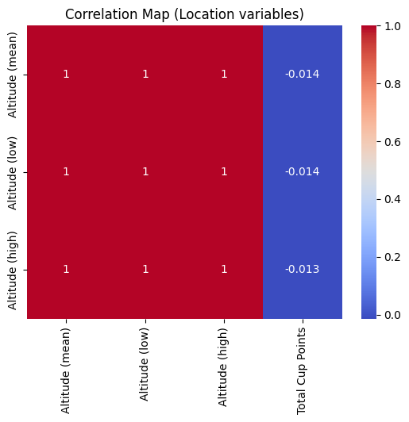

```python
numeric_data = coffee[['Altitude (mean)', 'Altitude (low)', 'Altitude (high)'] + ['Total Cup Points']].dropna()
location_correlation = numeric_data.corr().drop('Total Cup Points')

# Correlation heatmap
sns.heatmap(location_correlation, annot=True, cmap='coolwarm')

plt.title('Correlation Map (Location variables)')
plt.show()
```

If we analyze the data in general, the correlation between the altitude and the total cup points indicates that there is almost no relation between these variables, but we want to get the correlation divided by the country of origin.

```python
# Group by Country the correlation with the mean altitude
country_altitude_corr = coffee.groupby('Country').apply(
    lambda group: group[['Altitude (mean)', 'Total Cup Points']].corr().iloc[0, 1]).dropna().sort_values(ascending=False).reset_index()

country_altitude_corr.rename(columns={0:'Correlation'})
```

|  | Country | Correlation |
| --- | --- | --- |
| 0 | United States (Hawaii) | 1.000000 |
| 1 | Peru | 1.000000 |
| 2 | Ecuador | 1.000000 |
| 3 | Burundi | 1.000000 |
| 4 | Haiti | 0.742130 |
| 5 | Philippines | 0.726317 |
| 6 | India | 0.587434 |
| 7 | Uganda | 0.478961 |
| 8 | Ethiopia | 0.415867 |
| 9 | Taiwan | 0.399207 |
| 10 | Malawi | 0.399116 |
| 11 | Thailand | 0.381836 |
| 12 | United States | 0.274804 |
| 13 | Costa Rica | 0.235791 |
| 14 | Panama | 0.191214 |
| 15 | El Salvador | 0.125397 |
| 16 | Kenya | 0.112667 |
| 17 | Honduras | 0.048521 |
| 18 | Mexico | 0.042369 |
| 19 | Nicaragua | 0.037648 |
| 20 | Brazil | 0.027320 |
| 21 | Colombia | -0.006585 |
| 22 | Guatemala | -0.053725 |
| 23 | Tanzania, United Republic Of | -0.080831 |
| 24 | China | -0.107649 |
| 25 | Vietnam | -0.141472 |
| 26 | Myanmar | -0.150707 |
| 27 | Laos | -0.154993 |
| 28 | Indonesia | -0.565402 |

## Which farms, mills and producers have the most consistent coffee quality over time?

```python
# Calculate the standard deviation of 'total_cup_points' for each farm
farm_consistency = coffee.groupby('Farm')['Total Cup Points'].std().dropna().sort_values().reset_index()
farm_consistency.head()
```

|  | Farm | Total Cup Points |
| --- | --- | --- |
| 0 | gran manzana y el aguacate | 0.113137 |
| 1 | el barbaro | 0.113137 |
| 2 | gao chun fang 高醇坊 | 0.120208 |
| 3 | coopetarrazú | 0.120208 |
| 4 | la orduña, coatepec, veracruz | 0.120208 |

The farms that are most consistent with the coffee quality they produce are **Gran Manzana y El Aguacate and El Barbaro**, both with the lowest standar deviation of 0.113137.

```python
# Calculate the standard deviation of 'total_cup_points' for each mill
mill_consistency = coffee.groupby('Mill')['Total Cup Points'].std().dropna().sort_values().reset_index()
mill_consistency.head()
```

|  | Mill | Total Cup Points |
| --- | --- | --- |
| 0 | ibero | 0.000000 |
| 1 | el olvido, zentla, veracruz | 0.000000 |
| 2 | internacional armazens gerais | 0.056569 |
| 3 | 17/18 | 0.063640 |
| 4 | santa adelaida | 0.113137 |

The mills that are most consistent with the coffee quality they produce are **Ibero and El Olvido, Zentla, Veracruz**, both with the lowest standar deviation of 0.

```python
# Calculate the standard deviation of 'total_cup_points' for each producer
producer_consistency = coffee.groupby('Producer')['Total Cup Points'].std().dropna().sort_values().reset_index()
producer_consistency.head()
```

|  | Producer | Total Cup Points |
| --- | --- | --- |
| 0 | Santos Fonseca | 0.000000 |
| 1 | Maria Rogeria Costa Pereira | 0.000000 |
| 2 | Assefa Belay Coffee Producer | 0.056569 |
| 3 | COFFEE FOR PEACE,INC. | 0.113137 |
| 4 | El Barbaro, S.A. de C.V. | 0.113137 |

The producers that are most consistent with the coffee quality they produce are **Santos Fonseca and Maria Rogeria Costa Pereira**, both with the lowest standar deviation of 0.

These farms, mills and producers with the lowest standard deviation indicate stable growing conditions, more reliable practices, and consistent quality coffee.

# Bean Metadata Questions

## Which processing method is used the most?

```python
pm_counts = coffee['processing_method'].value_counts().reset_index()
print(pm_counts)
pm_bar = px.bar(pm_counts, x=pm_counts['processing_method'], y=pm_counts['count'])
pm_bar.show()
```

```
           processing_method  count
0               Washed / Wet    815
1              Natural / Dry    258
2  Semi-washed / Semi-pulped     56
3                      Other     26
4     Pulped natural / honey     14
```

[interactive chart not shown]

## Which processing method has the highest number of bags?

```python
pm_bags = coffee.groupby('processing_method')['Number of Bags'].sum().reset_index().sort_values(by='Number of Bags', ascending=False)
print(pm_bags)
pm_bags_bar = px.bar(pm_bags, x=pm_bags['processing_method'], y=pm_bags['Number of Bags'])
pm_bags_bar.show()
```

```
           processing_method  Number of Bags
4               Washed / Wet          128071
0              Natural / Dry           40581
3  Semi-washed / Semi-pulped            5304
1                      Other            3342
2     Pulped natural / honey            2341
```

[interactive chart not shown]

## Did any product get graded the same year it was harvested?

```python
# Clean grading_date column which is by default un-parseable for to_datetime
def remove_date_suffix(column):
    return re.sub(r"\b([0123]?[0-9])(st|th|nd|rd)\b",r"\1", column)
coffee['grading_date'] = coffee['grading_date'].apply(remove_date_suffix)
coffee['grading_date'] = pd.to_datetime(coffee['grading_date'], format='mixed')
```

```python
# Create and convert year to object dtype
coffee['year'] = coffee['grading_date'].dt.year
coffee['year'] = coffee['year'].astype(str)
```

```python
# Preliminary analysis of harvest vs graded year.
coffee['harvest_vs_grading_years'] = coffee['harvest_year'].equals(coffee['year'])
year_comparison = coffee['harvest_vs_grading_years'].value_counts().reset_index()
print(year_comparison)
```

```
   harvest_vs_grading_years  count
0                     False   1339
```